# Mini Proyecto 2026. Análisis de los *logs* de la asignatura en Aula Virtual durante el curso 2024-2025

Tratamiento de Datos. Grado en Ciencia de Datos- UV

Marcelino Martínez Sober

03 / 03 / 2026

# Introducción.

El objetivo de este proyecto es que os enfrentéis a un problema real de tratamiento de datos que abarque todas las etapas que estamos describiendo a lo largo del curso. El proyecto se realizará en grupos de trabajo, lo que os permitirá adquirir nuevas competencias relacionadas con el trabajo en equipo, distribución de tareas, puesta en común, resolución de problemas, responsabilidad dentro del grupo, etc.

- Cada grupo estará formado por 6 ó 7 personas distribuidas aleatoriamente (Ver grupos en Aula Virtual).
- El proyecto se realizará con control de cambios **GIT** y tendrá un repositorio con el nombre **ProyectoTD2026** en la **plataforma GitHub**, donde se irán reflejando los cambios realizados y la evolución en su desarrollo. **TODOS** los miembros del equipo deben participar realizando *commits*. **Solo se realizará control de cambios de los ficheros fuente**
- La carpeta del proyecto se llamará **ProyectoTD2026**, y contendrá:
  - Fichero **ProyectoTD2026.Rmd**, con el código.
  - Carpeta **data** con los datos.
  - Fichero **Presentacion_X_.pdf**. (Sustituye **X** por la letra de tu grupo) Pdf de la presentación que se empleará en clase. NO SE PODRÁ CAMBIAR.
  - Fichero **VideoGrupo_X_.avi**. (Sustituye **X** por la letra de tu grupo) video de duración máxima 8-10 minutos con vuestra presentación en la que participen todos los miembros del grupo. *If you are an exchange student, you may give your part of the presentation in Spanish or English.*.
  - Fichero de informe **ProyectoTD2026.html/ProyectoTD2026.pdf**, obtenido al ejecutar el programa que incluya código, resultados y comentarios detallados de cada uno de los pasos seguidos. **El tamaño máximo del informe debe ser de 10 páginas**.
  - Fichero **EnlaceRepo.txt** con una sola línea que almacenará el enlace al repositorio de GitHub.
  - El informe debe contener obligatoriamente los apartados:
    - Introducción.
    - Material y métodos.
    - Resultados
    - Conclusiones

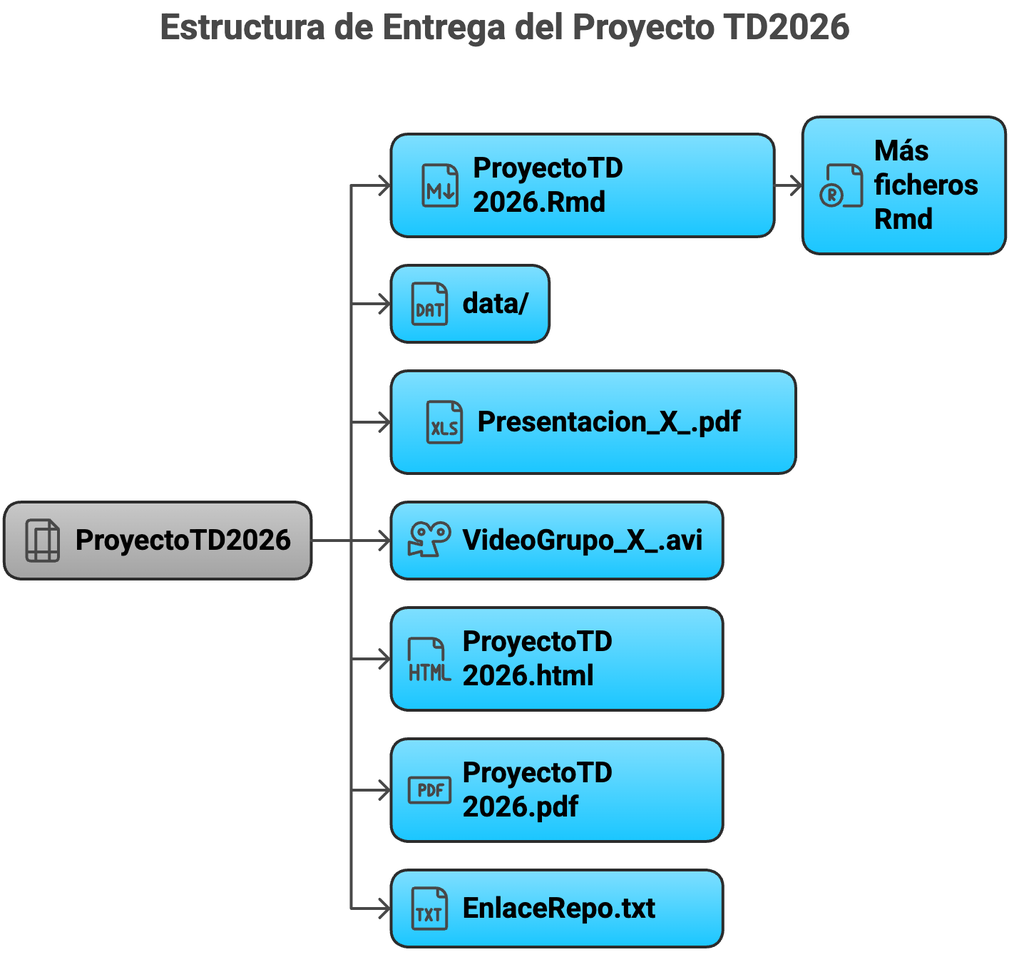

Estructura de la carpeta de entrega

**Las Figuras que se incluyan en el documento deberán tener pie de figura y estar referenciadas en el documento al igual que las tablas**. (Revisa el fichero plantilla del AV)

- El `13 de marzo` es la fecha límite para contactar con los compañeros de grupo, planificar el trabajo y completar la tabla de miembros “reales” de cada grupo en este enlace(https://docs.google.com/spreadsheets/d/1c3Cj7Xep4Tvct9bK_8602xKYFtEs3TCDfwvNroYJsAc/edit#gid=0) No puede haber ningún grupo con menos de 4 personas. Si se genera algún grupo pequeño se redistribuirá entre el resto de grupos.
- `Hasta el 6 de abril (incluido) FASE 1` subiréis la carpeta del proyecto que incluirá, la introducción e importación de los datos (debe aparecer una figura y una tabla numeradas y referenciadas en el texto) y el listado de preguntas que queréis responder al analizar los datos (posteriormente se pueden añadir más preguntas). **Cada uno de los miembros del grupo debe haber realizado al menos 1 commit**
- `Hasta el 6 de abril (incluido)` cada grupo, **al completo**, pasará por mi despacho (3.2.18), preferiblemente en horario de tutorías, y me mostrará la importación y adecuación de los datos, las preguntas que se ha planteado responder a partir de ellos y cómo se han repartido las tareas. Podéis aprovechar para preguntar dudas.
- El `15 de mayo a las 23:55` es la hora límite para subir al AV toda la información relacionada con el trabajo. El proyecto debe ser funcional y no generar errores de instalación de librerías, uso de rutas locales, etc. Una presentación en PowerPoint/Keynotes o similar es imprescindible. **La presentación (pdf) entregada será la que se utilice el día de la exposición. No se puede cambiar**.
- El `18 de mayo`, de 8:45-11:15, cada grupo realizará una presentación de 10 minutos (máximo), en la que deben participar **TODOS** los miembros del grupos comentando los resultados obtenidos. El orden de presentación de los miembros del grupo será aleatorio.
- Todos los miembros del grupo deben conocer cada una de las fases de trabajo.
- Dadas las limitaciones de tiempo empezaremos las presentaciones a las 8:45, si alquien tiene algún problema con el horario que se ponga en contacto conmigo.
- Cada grupo será evaluado por el resto de grupos mediante un cuestionario.
- Todos los alumnos deben estar en las presentaciones de los otros grupos.